# Análisis Factorial en R

Primero queremos importar los datos con los que vamos a trabajar. En este caso trabajaremos con stats de jugadores de basketball obtenidos del último videojuego de la NBA “NBA2K20”

```r
data <- read.csv(file = "2K20_ratings.csv")
data
```

| Player | Close.Shot | Mid.Range.Shot | Three.Point.Shot | Free.Throw | Shot.IQ | Offensive.Consistency | Speed | Acceleration | Strength | Vertical | Stamina | Hustle | Overall.Durability | Layup | Standing.Dunk | Driving.Dunk | Post.Hook | Post.Fade | Post.Control | Draw.Foul | Hands | Pass.Accuracy | Ball.Handle | Speed.with.Ball | Pass.IQ | Pass.Vision | Interior.Defense | Perimeter.Defense | Steal | … |
| --- | --- | --- | --- | --- | --- | --- | --- | --- | --- | --- | --- | --- | --- | --- | --- | --- | --- | --- | --- | --- | --- | --- | --- | --- | --- | --- | --- | --- | --- | --- |
| Aaron Gordon | 76 | 60 | 74 | 70 | 97 | 85 | 71 | 67 | 72 | 92 | 95 | 90 | 84 | 85 | 95 | 95 | 58 | 60 | 72 | 74 | 95 | 55 | 62 | 66 | 60 | 60 | 78 | 79 | 40 | … |
| Al Horford | 70 | 90 | 75 | 73 | 86 | 65 | 53 | 48 | 91 | 69 | 95 | 85 | 78 | 65 | 80 | 61 | 85 | 85 | 85 | 40 | 84 | 75 | 50 | 33 | 88 | 66 | 90 | 63 | 42 | … |
| Andre Drummond | 76 | 47 | 60 | 64 | 62 | 70 | 60 | 58 | 95 | 79 | 89 | 90 | 81 | 80 | 95 | 85 | 80 | 55 | 80 | 45 | 85 | 52 | 45 | 49 | 70 | 54 | 84 | 52 | 87 | … |
| Andrew Wiggins | 85 | 71 | 77 | 72 | 66 | 95 | 82 | 85 | 57 | 98 | 98 | 92 | 83 | 88 | 40 | 94 | 45 | 70 | 55 | 70 | 95 | 66 | 79 | 80 | 75 | 67 | 55 | 66 | 37 | … |
| Anthony Davis | 90 | 72 | 74 | 86 | 90 | 98 | 79 | 78 | 87 | 86 | 97 | 98 | 78 | 94 | 95 | 86 | 93 | 93 | 89 | 90 | 95 | 60 | 65 | 67 | 72 | 60 | 97 | 73 | 63 | … |
| Bam Adebayo | 91 | 78 | 56 | 68 | 97 | 95 | 70 | 69 | 84 | 85 | 95 | 93 | 90 | 79 | 90 | 80 | 76 | 68 | 78 | 84 | 95 | 64 | 60 | 59 | 74 | 71 | 85 | 69 | 49 | … |
| Ben Simmons | 80 | 46 | 47 | 63 | 98 | 98 | 93 | 84 | 80 | 85 | 97 | 97 | 83 | 96 | 83 | 87 | 76 | 73 | 79 | 96 | 98 | 75 | 87 | 84 | 89 | 79 | 80 | 88 | 90 | … |
| Blake Griffin | 75 | 45 | 61 | 78 | 80 | 70 | 68 | 71 | 94 | 90 | 95 | 95 | 88 | 78 | 98 | 93 | 74 | 74 | 85 | 72 | 98 | 75 | 75 | 66 | 74 | 66 | 78 | 59 | 33 | … |
| Bojan Bogdanovic | 75 | 68 | 85 | 90 | 90 | 95 | 67 | 62 | 60 | 72 | 87 | 85 | 84 | 73 | 40 | 70 | 49 | 60 | 64 | 64 | 70 | 69 | 74 | 66 | 72 | 39 | 54 | 78 | 35 | … |
| Bradley Beal | 85 | 87 | 80 | 83 | 98 | 98 | 76 | 83 | 56 | 87 | 98 | 78 | 82 | 94 | 30 | 75 | 55 | 55 | 44 | 90 | 81 | 77 | 86 | 76 | 85 | 74 | 45 | 74 | 41 | … |

[output cut: 90 more lines]

Pero queremos quedarnos sólo con las columnas numéricas, por lo tanto tenemos que quitarle la columna de Player

```r
df <- data[,c(2:37)]
df
```

| Close.Shot | Mid.Range.Shot | Three.Point.Shot | Free.Throw | Shot.IQ | Offensive.Consistency | Speed | Acceleration | Strength | Vertical | Stamina | Hustle | Overall.Durability | Layup | Standing.Dunk | Driving.Dunk | Post.Hook | Post.Fade | Post.Control | Draw.Foul | Hands | Pass.Accuracy | Ball.Handle | Speed.with.Ball | Pass.IQ | Pass.Vision | Interior.Defense | Perimeter.Defense | Steal | Block | … |
| --- | --- | --- | --- | --- | --- | --- | --- | --- | --- | --- | --- | --- | --- | --- | --- | --- | --- | --- | --- | --- | --- | --- | --- | --- | --- | --- | --- | --- | --- | --- |
| 76 | 60 | 74 | 70 | 97 | 85 | 71 | 67 | 72 | 92 | 95 | 90 | 84 | 85 | 95 | 95 | 58 | 60 | 72 | 74 | 95 | 55 | 62 | 66 | 60 | 60 | 78 | 79 | 40 | 52 | … |
| 70 | 90 | 75 | 73 | 86 | 65 | 53 | 48 | 91 | 69 | 95 | 85 | 78 | 65 | 80 | 61 | 85 | 85 | 85 | 40 | 84 | 75 | 50 | 33 | 88 | 66 | 90 | 63 | 42 | 65 | … |
| 76 | 47 | 60 | 64 | 62 | 70 | 60 | 58 | 95 | 79 | 89 | 90 | 81 | 80 | 95 | 85 | 80 | 55 | 80 | 45 | 85 | 52 | 45 | 49 | 70 | 54 | 84 | 52 | 87 | 80 | … |
| 85 | 71 | 77 | 72 | 66 | 95 | 82 | 85 | 57 | 98 | 98 | 92 | 83 | 88 | 40 | 94 | 45 | 70 | 55 | 70 | 95 | 66 | 79 | 80 | 75 | 67 | 55 | 66 | 37 | 60 | … |
| 90 | 72 | 74 | 86 | 90 | 98 | 79 | 78 | 87 | 86 | 97 | 98 | 78 | 94 | 95 | 86 | 93 | 93 | 89 | 90 | 95 | 60 | 65 | 67 | 72 | 60 | 97 | 73 | 63 | 89 | … |
| 91 | 78 | 56 | 68 | 97 | 95 | 70 | 69 | 84 | 85 | 95 | 93 | 90 | 79 | 90 | 80 | 76 | 68 | 78 | 84 | 95 | 64 | 60 | 59 | 74 | 71 | 85 | 69 | 49 | 72 | … |
| 80 | 46 | 47 | 63 | 98 | 98 | 93 | 84 | 80 | 85 | 97 | 97 | 83 | 96 | 83 | 87 | 76 | 73 | 79 | 96 | 98 | 75 | 87 | 84 | 89 | 79 | 80 | 88 | 90 | 53 | … |
| 75 | 45 | 61 | 78 | 80 | 70 | 68 | 71 | 94 | 90 | 95 | 95 | 88 | 78 | 98 | 93 | 74 | 74 | 85 | 72 | 98 | 75 | 75 | 66 | 74 | 66 | 78 | 59 | 33 | 51 | … |
| 75 | 68 | 85 | 90 | 90 | 95 | 67 | 62 | 60 | 72 | 87 | 85 | 84 | 73 | 40 | 70 | 49 | 60 | 64 | 64 | 70 | 69 | 74 | 66 | 72 | 39 | 54 | 78 | 35 | 32 | … |
| 85 | 87 | 80 | 83 | 98 | 98 | 76 | 83 | 56 | 87 | 98 | 78 | 82 | 94 | 30 | 75 | 55 | 55 | 44 | 90 | 81 | 77 | 86 | 76 | 85 | 74 | 45 | 74 | 41 | 47 | … |

[output cut: 90 more lines]

Ahora podemos obtener la matriz de correlación de los datos

```r
df_corr <- cor(df)
```

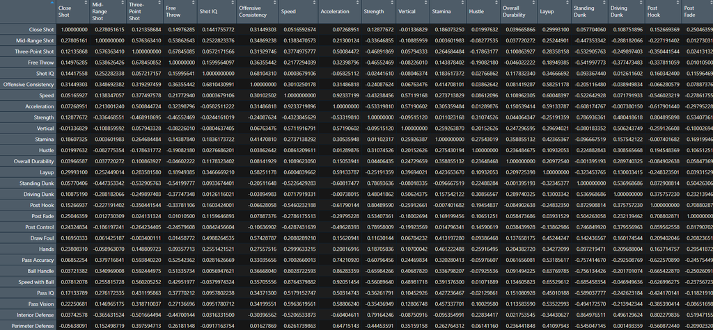

Matriz de correlación

Ahora importamos la librería que nos va ayudar a hacer el análisis factorial, que es library(psych)

```r
library(psych)
```

Y antes de hacer el análisis queremos ver cuáles son las variables que son aptas para este método, por lo cual antes haremos la prueba Kaiser-Meyer-Olkin (KMO). Para más información sobre este método pueden visitar el siguiente link: https://www.statisticshowto.com/kaiser-meyer-olkin/

```r
KMO(df_corr)
```

```
Kaiser-Meyer-Olkin factor adequacy
Call: KMO(r = df_corr)
Overall MSA =  0.87
MSA for each item =
           Close Shot        Mid-Range Shot      Three-Point Shot
                 0.59                  0.79                  0.88
           Free Throw               Shot IQ Offensive Consistency
                 0.90                  0.58                  0.75
                Speed          Acceleration              Strength
                 0.91                  0.90                  0.93
             Vertical               Stamina                Hustle
                 0.75                  0.77                  0.67
   Overall Durability                 Layup         Standing Dunk
                 0.61                  0.90                  0.93
         Driving Dunk             Post Hook             Post Fade
                 0.75                  0.91                  0.83
         Post Control             Draw Foul                 Hands
                 0.87                  0.69                  0.77
        Pass Accuracy           Ball Handle       Speed with Ball
                 0.95                  0.89                  0.91
              Pass IQ           Pass Vision      Interior Defense
                 0.88                  0.86                  0.94
    Perimeter Defense                 Steal                 Block
                 0.91                  0.81                  0.89
    Lateral Quickness       Help Defense IQ       Pass Perception
                 0.90                  0.76                  0.82
Defensive Consistency     Offensive Rebound     Defensive Rebound
                 0.71                  0.90                  0.89
```

Esta prueba nos regresa el MSA o Measure of Sample Adequacy. En nuestro caso vemos que el overall MSA es de 0.87, por lo cual en general estos datos sí se adecuan mucho para un análisis factorial, pero también vemos que hay algunas variables que presentan un MSA muy bajo, por lo cual las quitaremos con el fin de tratar de mejorar el overall MSA un poco.

```r
df1 <- df[,c('Mid-Range Shot', 'Three-Point Shot', 'Free Throw', 'Offensive Consistency', 'Speed', 'Acceleration', 'Strength','Vertical', 'Stamina','Layup','Standing Dunk', 'Driving Dunk', 'Post Hook', 'Post Fade','Post Control', 'Draw Foul', 'Hands', 'Pass Accuracy', 'Ball Handle','Speed with Ball', 'Pass IQ', 'Pass Vision', 'Interior Defense','Perimeter Defense', 'Steal', 'Block', 'Lateral Quickness','Help Defense IQ', 'Pass Perception', 'Defensive Consistency','Offensive Rebound', 'Defensive Rebound')]
```

```r
df_corr1 <- cor(df1)
KMO(df_corr1)
```

```
Kaiser-Meyer-Olkin factor adequacy
Call: KMO(r = df_corr1)
Overall MSA =  0.88
MSA for each item =
       Mid-Range Shot      Three-Point Shot            Free Throw
                 0.83                  0.88                  0.91
Offensive Consistency                 Speed          Acceleration
                 0.74                  0.92                  0.91
             Strength              Vertical               Stamina
                 0.92                  0.76                  0.80
                Layup         Standing Dunk          Driving Dunk
                 0.88                  0.94                  0.75
            Post Hook             Post Fade          Post Control
                 0.91                  0.83                  0.86
            Draw Foul                 Hands         Pass Accuracy
                 0.65                  0.76                  0.95
          Ball Handle       Speed with Ball               Pass IQ
                 0.89                  0.91                  0.89
          Pass Vision      Interior Defense     Perimeter Defense
                 0.85                  0.94                  0.90
                Steal                 Block     Lateral Quickness
                 0.83                  0.89                  0.91
      Help Defense IQ       Pass Perception Defensive Consistency
                 0.77                  0.81                  0.74
    Offensive Rebound     Defensive Rebound
                 0.92                  0.90
```

Podemos observar que el overall MSA sí aumenta un poco y se podría aumentar más aunque por el momento es un MSA muy decente para poder aplicar análisis factorial

Pero antes de aplicar el análisis factorial tenemos que definir la cantidad de factores, por lo cual primero haré un plot de la matriz de correlación, el cual nos puede dar una idea de la cantidad de factores que deberiamos elegir

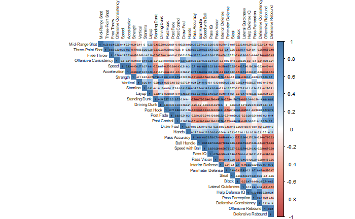

```r
library(corrplot)
df1_corr <- cor(df1)
col <- colorRampPalette(c("#BB4444", "#EE9988", "#FFFFFF", "#77AADD", "#4477AA"))
cex.before <- par("cex") #Cambiar tamaño de los números en del corrplot
par(cex = 0.3)
corrplot(round(df1_corr, 2), method="color", col=col(200),
         type="upper", order="original",
         addCoef.col = "black",
         tl.col="black", tl.srt=90,
         diag=TRUE,tl.cex = 1.6,
        cl.cex = 2, addCoefasPercent = FALSE)
```

En este caso vemos que la representación no nos ayuda mucho pero en casos con menos varibles tal vez nos hubiera podido dar una idea más clara.

Ahora sí lo que podemos hacer para poder tener un mejor método para decidir la cantidad de factores, es usar la función “fa” de la libreria psych, que nos va ayudar a hacer un análisis exploratorio de factores

```r
nfactors <- 8
nvars <- dim(df1_corr)[1]
#Es muy importante especificar ml(maximum likelihood) como el método
factors <- fa(r = df1_corr, nfactors = nfactors, rotate = "Varimax", fm="ml")
factors
```

```
Factor Analysis using method =  ml
Call: fa(r = df1_corr, nfactors = nfactors, rotate = "Varimax",
    fm = "ml")
Standardized loadings (pattern matrix) based upon correlation matrix
```

|  | ML1 | ML3 | ML4 | ML2 | ML5 | ML6 | ML8 | ML7 | h2 | u2 | com |
| --- | --- | --- | --- | --- | --- | --- | --- | --- | --- | --- | --- |
| Mid-Range Shot | 0.11 | -0.15 | 0.50 | -0.12 | 0.00 | 0.21 | -0.29 | 0.06 | 0.4355487 | 0.56445126 | 2.539529 |
| Three-Point Shot | 0.38 | -0.14 | 0.68 | -0.14 | 0.09 | 0.09 | -0.11 | -0.02 | 0.6824096 | 0.31759038 | 1.933194 |
| Free Throw | 0.19 | -0.19 | 0.68 | -0.15 | 0.12 | 0.14 | -0.21 | 0.03 | 0.6297256 | 0.37027437 | 1.841622 |
| Offensive Consistency | 0.18 | -0.04 | 0.19 | -0.21 | 0.10 | 0.84 | -0.04 | 0.03 | 0.8307218 | 0.16927819 | 1.385118 |
| Speed | 0.90 | -0.25 | -0.03 | 0.01 | 0.13 | 0.15 | 0.04 | -0.06 | 0.9099142 | 0.09008577 | 1.274314 |
| Acceleration | 0.90 | -0.31 | 0.13 | -0.03 | 0.08 | 0.12 | 0.06 | -0.16 | 0.9771608 | 0.02283922 | 1.430347 |
| Strength | -0.31 | 0.75 | -0.29 | 0.10 | 0.01 | -0.07 | 0.17 | -0.10 | 0.7952587 | 0.20474128 | 1.902216 |
| Vertical | 0.60 | -0.06 | -0.14 | -0.01 | -0.11 | 0.01 | 0.58 | -0.02 | 0.7436304 | 0.25636963 | 2.209773 |
| Stamina | 0.21 | 0.09 | 0.18 | 0.18 | 0.41 | 0.43 | 0.34 | -0.14 | 0.6090563 | 0.39094365 | 4.534626 |
| Layup | 0.56 | -0.04 | 0.10 | 0.01 | 0.22 | 0.51 | 0.11 | 0.14 | 0.6701062 | 0.32989376 | 2.603081 |

[output cut: 22 more lines]

```
                       ML1  ML3  ML4  ML2  ML5  ML6  ML8  ML7
SS loadings           6.81 6.40 3.04 3.02 2.23 2.02 1.10 0.31
Proportion Var        0.21 0.20 0.09 0.09 0.07 0.06 0.03 0.01
Cumulative Var        0.21 0.41 0.51 0.60 0.67 0.74 0.77 0.78
Proportion Explained  0.27 0.26 0.12 0.12 0.09 0.08 0.04 0.01
Cumulative Proportion 0.27 0.53 0.65 0.77 0.86 0.94 0.99 1.00

Mean item complexity =  2.4
Test of the hypothesis that 8 factors are sufficient.

The degrees of freedom for the null model are  496  and the objective function was  41.81
The degrees of freedom for the model are 268  and the objective function was  4.52

The root mean square of the residuals (RMSR) is  0.02
The df corrected root mean square of the residuals is  0.03

Fit based upon off diagonal values = 1
Measures of factor score adequacy
                                                   ML1  ML3  ML4  ML2
Correlation of (regression) scores with factors   0.98 0.98 0.94 0.97
Multiple R square of scores with factors          0.97 0.96 0.88 0.95
Minimum correlation of possible factor scores     0.93 0.91 0.76 0.89
                                                   ML5  ML6  ML8  ML7
Correlation of (regression) scores with factors   0.92 0.92 0.88 0.86
Multiple R square of scores with factors          0.85 0.84 0.77 0.75
Minimum correlation of possible factor scores     0.70 0.68 0.54 0.50
```

Con la información del análisis exploratorio de factores podemos ver que 4 o 5 factores serían lo ideal, pero para estar seguros podemos hacer otra prueba que consiste en analizar la varinza que guarda cada eigenvector. Para esto podemos hacer otro plot.

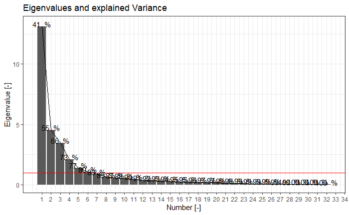

```r
library(ggplot2)
# Del analisis anterior podemos sacar los eigenvalores
eigenvalues <- data.frame(factors$e.values)
colnames(eigenvalues) <- c("Values")
eigenvalues$Number <- 1:nrow(df1_corr)

eigenvalues$RepresentedVariance <- NA
for (i in 1:nrow(df1_corr)) {
    eigenvalues$RepresentedVariance[i] <- sum(eigenvalues$Values[1:i])/sum(eigenvalues$Values) *
        100
}
eigenvalues$RepresentedVariance_text <- paste(round(eigenvalues$RepresentedVariance,
    0), " %")

e1 <- ggplot(eigenvalues, aes(Number, y = Values), group = 1)
e1 <- e1 + geom_bar(stat = "identity")
e1 <- e1 + geom_line(aes(y = Values), group = 2)
e1 <- e1 + xlab("Number [-]")
e1 <- e1 + ylab("Eigenvalue [-]")
e1 <- e1 + geom_hline(aes(yintercept = 1), col = "red")
e1 <- e1 + geom_text(aes(label = RepresentedVariance_text), nudge_y = 0.2)
e1 <- e1 + ggtitle("Eigenvalues and explained Variance")
e1 <- e1 + theme_bw()
e1 <- e1 + scale_x_continuous(breaks = seq(1, 34, 1))
e1
```

```r
nfactors <- 5 # Based on the screeplot suggestion
nvars <- dim(df1_corr)[1]
factors <- fa(r = df1_corr, nfactors = nfactors, rotate = "Varimax", fm="ml")
factors
```

[output not shown]

Podemos representar los factores y sus varibles en un plot

```r
library(dplyr)
library(tidyr)
loadings_mat <- as.data.frame(matrix(nrow = nvars, ncol =nfactors))
loadings_mat$Variable <- colnames(df1)
for (i in 1:nfactors) {
  for (j in 1:nvars) {
    loadings_mat[j, i] <- factors$loadings[j, i]
  }
}
colnames(loadings_mat) <- c("Factor1","Factor2", "Factor3", "Factor4","Factor5","Variable")
loadings_mat_gather <- loadings_mat %>% gather("Factor", "Value", 1:nfactors)
loadings_mat_gather
```

| Variable | Factor | Value |
| --- | --- | --- |
| Mid-Range Shot | Factor1 | -0.182663215 |
| Three-Point Shot | Factor1 | -0.197364416 |
| Free Throw | Factor1 | -0.233123113 |
| Offensive Consistency | Factor1 | 0.028209327 |
| Speed | Factor1 | -0.286112268 |
| Acceleration | Factor1 | -0.355238452 |
| Strength | Factor1 | 0.772662526 |
| Vertical | Factor1 | -0.032480619 |
| Stamina | Factor1 | 0.146150044 |
| Layup | Factor1 | -0.014965943 |

[output cut: 150 more lines]

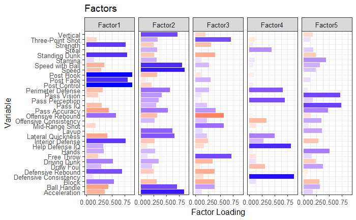

```r
g1 <- ggplot(loadings_mat_gather, aes(Variable, abs(Value), fill=Value))
g1 <- g1 + facet_wrap(~ Factor, nrow=1)
g1 <- g1 + geom_bar(stat="identity")
g1 <- g1 + coord_flip()
g1 <- g1 + scale_fill_gradient2(name = "Loading",
                       high = "blue", mid = "white", low = "red",
                       midpoint=0, guide=F)
g1 <- g1 + xlab("Variable")  # improve x-axis label
g1 <- g1 + ylab("Factor Loading")  #improve y-axis label
g1 <- g1 + ggtitle("Factors")
g1 <- g1 + theme(axis.text=element_text(size=10),
        axis.title=element_text(size=12, face="bold"))
g1 <- g1 + theme(plot.title = element_text(size=12))
g1 <- g1 + theme_bw(base_size=12)
g1
```

En este gráfico podemos ver claramente cómo cada varible “encaja” en cada factor. Podemos ver qué tanta correlación tiene cada variable con cada factor.

Y para terminar también vamos a generar una gráfica para el analisis factorial realizado en pasos previos

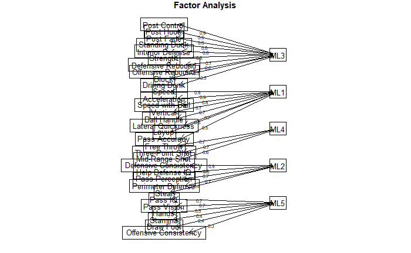

```r
cex.before <- par("cex") #Cambiar tamaño de los números en del corrplot
par(cex = 0.8)
fa.diagram(factors, rsize = 2, e.size = 0.03, side=5)
```